# day3_bulk_DEG.R

hhat

2026-03-11

**補足**: このスクリプトでは `#'` で始まる行はマークダウンとして扱われます。 HTMLレポートを生成する際（`rmarkdown::render()`）に、見出し・説明文として レンダリングされます。RStudioで通常実行する場合はコメントとして無視されるため、 動作に影響はありません。 # 作業ディレクトリとデータパスの設定

RStudioで開いたら、まず作業ディレクトリを設定してください。 以下のパスをご自身の環境に合わせて変更してください。

```r
# --- macOS の場合 ---
# project_dir <- "~/Downloads/bioinformatics-course-keio-2025-day3"

# --- Windows の場合 ---
# project_dir <- "C:/Users/あなたのユーザー名/Downloads/bioinformatics-course-keio-2025-day3"

project_dir <- "~/Downloads/bioinformatics-course-keio-2025-day3"  # ← 自分の環境に合わせて変更
setwd(project_dir)

data_dir     <- file.path(project_dir, "data", "bulk")
meta_file    <- file.path(project_dir, "data", "bulk", "sample_meta.txt")
ifn_genes_file     <- file.path(project_dir, "data", "bulk", "IFNgenes100.txt")
img_dir      <- file.path(project_dir, "img")
```

# ライブラリの読み込み

```r
library(ggplot2)
library(dplyr)
library(edgeR)
library(ggrepel)
library(gplots)
library(variancePartition)
```

# 使用するデータについて

本実習では、末梢血から28種類の免疫細胞をFACSで分離しBulk RNA-seqを 行った公開データを使用します。 健常者（HC）とSLE（全身性エリテマトーデス）患者のTh1細胞について、 DEG（発現変動遺伝子）解析を行います。 # メタデータの読み込み

```r
meta <- read.table(meta_file, header = T)
table(meta$disease)
```

```
##
##   HC  IIM MCTD   RA  SLE  SSc  TAK
##   64   42   19   19   62   46   16
```

# DEG解析（SLE vs HC、Th1細胞）

## Th1のカウントデータ読み込み

```r
file <- file.path(data_dir, "Th1_count.txt")
data <- read.table(file, header = TRUE, sep = "\t", stringsAsFactors = FALSE)
dim(data)
```

```
## [1] 53344   266
```

```r
HC_SLE_samples <- meta %>% filter(disease %in% c("HC", "SLE")) %>% pull(id)

# Th1が欠損していないサンプルに絞る
HC_SLE_samples <- intersect(colnames(data), HC_SLE_samples)
# HC,SLEサンプルだけに絞る
HC_SLE_cols <- intersect(colnames(data), c("Gene_id", "Gene_name", HC_SLE_samples))
data <- data %>% select(all_of(HC_SLE_cols))
dim(data)
```

```
## [1] 53344   127
```

```r
head(data)
```

```
##              Gene_id Gene_name NW100766 NW102196 NW102537 NW103721 NW103984 NW105357
## 1 ENSG00000000419.12      DPM1      464      407      688      599      542      660
## 2 ENSG00000000457.13     SCYL3      374      387      570      581      432      512
## 3 ENSG00000000460.16  C1orf112      138       80      179       90      120      115
## 4 ENSG00000000938.12       FGR      166      330        6       58       29      427
## 5 ENSG00000000971.15       CFH      246      445      261      289      193      166
## 6 ENSG00000001036.13     FUCA2      271      207      360      304      377      385
##   NW107292 NW107509 NW108551 NW109068 NW109502 NW109907 NW110185 NW111702 NW111772
## 1      500      496      584      450      539      631      577      604      491
## 2      196      451      459      473      451      498      344      547      384
## 3       41      111       93      125      256      108      242      103       53
## 4      658       16       46       31       21        6       86        2       67
## 5      107      255      188      287      224       99       58      203      276
## 6      239      243      237      224      341      301      366      246      218
##   NW113304 NW115281 NW116208 NW116520 NW116788 NW118087 NW120823 NW122223 NW122349
```

[output cut: 90 more lines]

## TMM正規化

TMM (Trimmed Mean of M-values) 正規化： サンプル間の総リード数の違いを補正する手法。 2サンプル間の遺伝子ごとの発現比（M値）を計算し、 極端に大きい/小さい上下の一定割合をトリム（除外）した上で 残りの平均をとることで、安定した正規化係数を推定する。

> Reference: Robinson MD, Oshlack A. “A scaling normalization method for differential expression analysis of RNA-seq data.” Genome Biology. 2010;11:R25. [doi:10.1186/gb-2010-11-3-r25](https://doi.org/10.1186/gb-2010-11-3-r25)

```r
gene_info <- data %>% select(Gene_id, Gene_name)
count_matrix <- data %>% select(-Gene_id, -Gene_name)
rownames(count_matrix) <- data$Gene_id

dge <- DGEList(counts = as.matrix(count_matrix))

# フィルタリング（低発現遺伝子の除去）
sample_percentage <- 0.1
min_samples <- ceiling(ncol(dge) * sample_percentage)
keep <- rowSums(cpm(dge) > 1) >= min_samples
dge_filtered <- dge[keep, ]
print(paste0("フィルタリング後の遺伝子数: ", nrow(dge_filtered), " / 元の遺伝子数: ", nrow(dge)))
```

```
## [1] "フィルタリング後の遺伝子数: 15357 / 元の遺伝子数: 53344"
```

```r
dge_filtered <- calcNormFactors(dge_filtered, method = "TMM")
log_cpm <- cpm(dge_filtered, log = TRUE)
```

## PCAとは

PCA（主成分分析）は、高次元データの次元を削減し、データの構造を 可視化するための手法です。

```r
# --- PCA概念図 ---
browseURL(file.path(img_dir, "pca_concept.png"))
```

## PCA（HC vs SLE）

```r
gene_variance <- apply(log_cpm, 1, var)
top_genes_indices <- order(gene_variance, decreasing = TRUE)[1:min(5000, length(gene_variance))]
expression_top <- log_cpm[top_genes_indices, ]

# prcomp() は「行=観測、列=変数」として入力を解釈する。
# 今回はサンプル間の関係を見たいので「行=サンプル、列=遺伝子」で渡す。
# expression_top は [遺伝子 × サンプル] なので転置が必要。
#
# 入力の向きで $x, $rotation の中身の意味が変わる：
#   行=サンプル、列=遺伝子 → $x=サンプルのスコア、$rotation=遺伝子の重み
#   行=遺伝子、列=サンプル → $x=遺伝子のスコア、$rotation=サンプルの重み
expression_top_t <- t(expression_top)  # [サンプル × 遺伝子] に変換
pca_result <- prcomp(expression_top_t, center = TRUE, scale = TRUE)

var_explained <- pca_result$sdev^2 / sum(pca_result$sdev^2)
pc1_var <- round(var_explained[1] * 100, 1)
pc2_var <- round(var_explained[2] * 100, 1)

pca_df <- as.data.frame(pca_result$x[, 1:2])
pca_df$id <- rownames(pca_df)
pca_df$disease <- left_join(pca_df, meta, by = c("id" = "id")) %>% pull(disease)
pca_df$disease <- factor(pca_df$disease)
```

### PCAプロット（HC vs SLE）

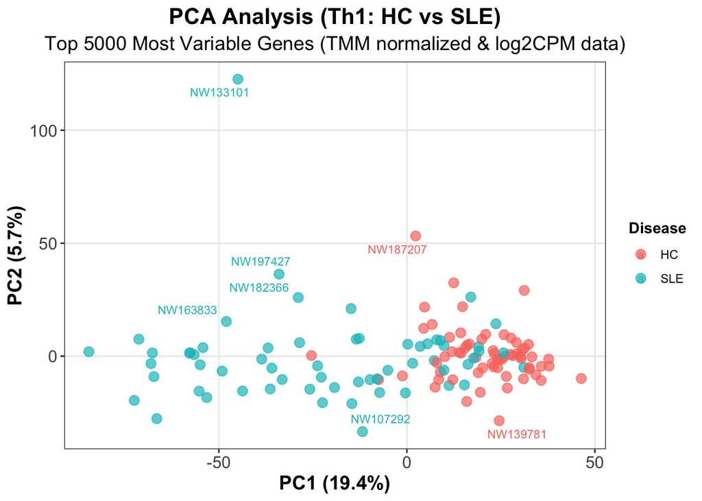

```r
pca_plot_disease <- ggplot(pca_df, aes(x = PC1, y = PC2, color = disease)) +
  geom_point(size = 3, alpha = 0.7) +
  geom_text_repel(
    aes(label = id),
    size = 3,
    box.padding = 0.35,
    point.padding = 0.5,
    segment.color = "grey50",
    max.overlaps = 2
  ) +
  labs(
    title = "PCA Analysis (Th1: HC vs SLE)",
    subtitle = paste0("Top ", length(top_genes_indices), " Most Variable Genes (TMM normalized & log2CPM data)"),
    x = paste0("PC1 (", pc1_var, "%)"),
    y = paste0("PC2 (", pc2_var, "%)"),
    color = "Disease"
  ) +
  theme_bw() +
  theme(
    plot.title = element_text(hjust = 0.5, face = "bold", size = 16),
    plot.subtitle = element_text(hjust = 0.5, size = 14),
    legend.position = "right",
    legend.title = element_text(face = "bold"),
    panel.grid.minor = element_blank(),
    axis.title = element_text(face = "bold", size = 14),
    axis.text = element_text(size = 12)
  ) +
  coord_cartesian(expand = TRUE)

print(pca_plot_disease)
```

## PCAについて補足：prcompの結果の中身を理解する

`prcomp()` は入力の「行=観測、列=変数」として解釈する。 今回は行=サンプル、列=遺伝子として渡したので、以下のように解釈される。 もし転置せず行=遺伝子で渡すと、`$x` は遺伝子のスコア、`$rotation` は サンプルの重みとなり、意味が変わるので注意。

`prcomp()` は以下の要素を返す（行=サンプル、列=遺伝子で入力した場合）：

| オブジェクト | 中身 | 次元 |
| --- | --- | --- |
| `pca_result$x` | 主成分スコア（サンプルのPC空間での座標）。PCAプロットのx軸・y軸の値はここから来る | サンプル数 × PC数 |
| `pca_result$rotation` | ローディング（因子負荷量）。“rotation”という名前だが実態はloading。各PCを作るとき元の各遺伝子にかける重み。例：PC1 = gene1×0.02 + gene2×(-0.01) + … 重みの絶対値が大きい遺伝子ほどそのPCを特徴づけている | 遺伝子数 × PC数 |
| `pca_result$sdev` | 各PCの標準偏差。sdev<sup>2/sum(sdev</sup>2) = 分散説明率 | PC数 |
| `pca_result$center` | 中心化に使った各遺伝子の平均値 | 遺伝子数 |
| `pca_result$scale` | スケーリングに使った各遺伝子の標準偏差 | 遺伝子数 |

数学的には **X = P V^T** （img/pca_concept.png の図中の X, P, V に対応）

- X = 中心化・スケーリング後の元データ [n×p] (n=サンプル数, p=遺伝子数)
- P = `pca_result$x` （主成分スコア） [n×r]
- V = `pca_result$rotation` （因子負荷量） [p×r] ### prcomp結果の構造

```r
str(pca_result)
```

```
## List of 5
##  $ sdev    : num [1:125] 31.2 16.8 12.4 10.8 10.1 ...
##  $ rotation: num [1:5000, 1:125] -0.00382 -0.00119 -0.00558 -0.02199 0.00234 ...
##   ..- attr(*, "dimnames")=List of 2
##   .. ..$ : chr [1:5000] "ENSG00000134184.12" "ENSG00000175164.13" "ENSG00000204644.9" "ENSG00000165949.12" ...
##   .. ..$ : chr [1:125] "PC1" "PC2" "PC3" "PC4" ...
##  $ center  : Named num [1:5000] 1.135 0.447 1.357 5.044 1.396 ...
##   ..- attr(*, "names")= chr [1:5000] "ENSG00000134184.12" "ENSG00000175164.13" "ENSG00000204644.9" "ENSG00000165949.12" ...
##  $ scale   : Named num [1:5000] 3.42 2.89 2.8 2.74 2.73 ...
##   ..- attr(*, "names")= chr [1:5000] "ENSG00000134184.12" "ENSG00000175164.13" "ENSG00000204644.9" "ENSG00000165949.12" ...
##  $ x       : num [1:125, 1:125] -1.2 19.09 15.51 11.35 4.48 ...
##   ..- attr(*, "dimnames")=List of 2
##   .. ..$ : chr [1:125] "NW100766" "NW102196" "NW102537" "NW103721" ...
##   .. ..$ : chr [1:125] "PC1" "PC2" "PC3" "PC4" ...
##  - attr(*, "class")= chr "prcomp"
```

### 主成分スコア [サンプル数 × PC数]

行がサンプル、列がPC。PCAプロットの座標そのもの。

```r
cat("pca_result$x の次元:", dim(pca_result$x), "(サンプル数 × PC数)\n")
```

```
## pca_result$x の次元: 125 125 (サンプル数 × PC数)
```

```r
print("主成分スコア（最初の5サンプル × 5PC）:")
```

```
## [1] "主成分スコア（最初の5サンプル × 5PC）:"
```

```r
print(head(pca_result$x, 5)[, 1:min(5, ncol(pca_result$x))])
```

```
##                PC1       PC2          PC3       PC4       PC5
## NW100766 -1.196692 -8.727079   0.25342114 -13.10787 -5.458338
## NW102196 19.094433  4.190001  22.66533592  -5.52400  0.107613
## NW102537 15.505175  3.607908 -14.99680634 -11.29627 -1.781911
## NW103721 11.352038  8.318144  -0.02800351  -8.33178 -1.449254
## NW103984  4.477724 12.341379  -4.58753436   5.48167 -5.188322
```

### ローディング [遺伝子数 × PC数]

“rotation”という名前だが実態はローディング（loading）。 PC1 = gene1×w1 + gene2×w2 + … という線形結合の重み(w)が格納されている。

```r
cat("pca_result$rotation の次元:", dim(pca_result$rotation), "(遺伝子数 × PC数)\n")
```

```
## pca_result$rotation の次元: 5000 125 (遺伝子数 × PC数)
```

```r
print("ローディング（最初の5遺伝子 × 5PC）:")
```

```
## [1] "ローディング（最初の5遺伝子 × 5PC）:"
```

```r
print(head(pca_result$rotation, 5)[, 1:min(5, ncol(pca_result$rotation))])
```

```
##                             PC1           PC2          PC3          PC4          PC5
## ENSG00000134184.12 -0.003824476  0.0007599976  0.017338337  0.008761922 -0.005601966
## ENSG00000175164.13 -0.001194935  0.0026757462  0.005165341  0.002494942  0.009369190
## ENSG00000204644.9  -0.005576853  0.0063811463 -0.004332424 -0.002028754  0.008100025
## ENSG00000165949.12 -0.021992224 -0.0047522010 -0.001696783  0.038327325  0.025330530
## ENSG00000204792.2   0.002339547  0.0052182634  0.003541341 -0.006164995 -0.003523514
```

### 各主成分の分散説明率

sdev[i]^2 / sum(sdev^2) = PC_i が全体の分散の何%を説明するか

```r
cat("pca_result$sdev の長さ:", length(pca_result$sdev), "(PC数)\n")
```

```
## pca_result$sdev の長さ: 125 (PC数)
```

```r
print("各主成分の標準偏差（上位6つ）:")
```

```
## [1] "各主成分の標準偏差（上位6つ）:"
```

```r
head(round(pca_result$sdev, 2))
```

```
## [1] 31.16 16.81 12.40 10.75 10.07  9.70
```

```r
print("各主成分の分散説明率（上位6つ）:")
```

```
## [1] "各主成分の分散説明率（上位6つ）:"
```

```r
head(round(var_explained, 4))
```

```
## [1] 0.1942 0.0565 0.0307 0.0231 0.0203 0.0188
```

```r
print("累積分散説明率（上位6つ）:")
```

```
## [1] "累積分散説明率（上位6つ）:"
```

```r
head(round(cumsum(var_explained), 4))
```

```
## [1] 0.1942 0.2507 0.2815 0.3046 0.3249 0.3437
```

### Scree plot（分散説明率の可視化）

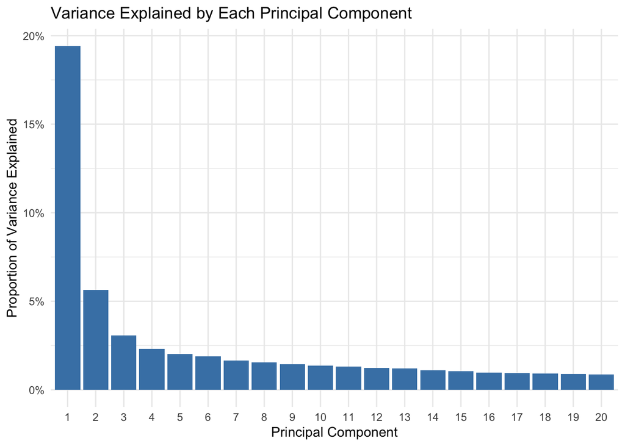

```r
n_components <- min(20, length(pca_result$sdev))

pca_var_df <- data.frame(
  PC = factor(1:n_components, levels = 1:n_components),
  Proportion = var_explained[1:n_components],
  Cumulative = cumsum(var_explained)[1:n_components]
)

# 各主成分の分散説明率
print(
  ggplot(pca_var_df, aes(x = PC, y = Proportion)) +
    geom_col(fill = "steelblue") +
    scale_y_continuous(labels = scales::percent_format()) +
    labs(
      title = "Variance Explained by Each Principal Component",
      x = "Principal Component",
      y = "Proportion of Variance Explained"
    ) +
    theme_minimal()
)
```

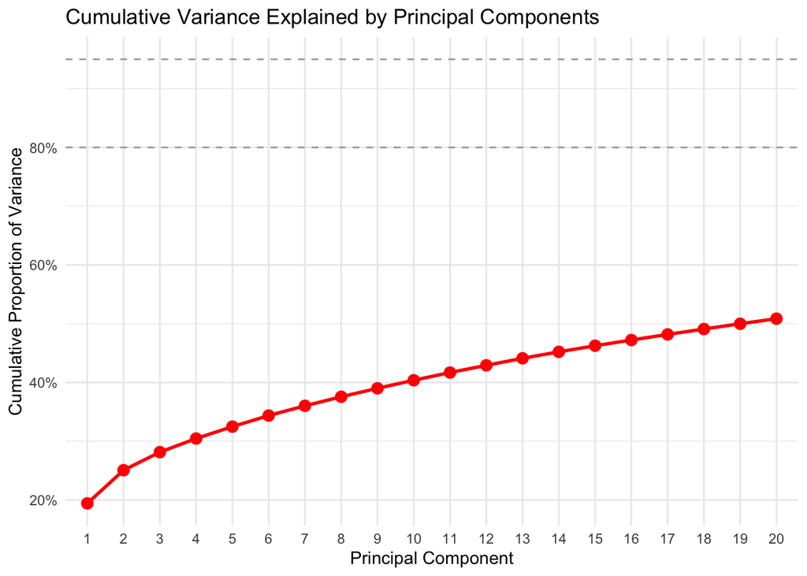

```r
# 累積分散説明率
print(
  ggplot(pca_var_df, aes(x = PC, y = Cumulative, group = 1)) +
    geom_line(color = "red", linewidth = 1) +
    geom_point(color = "red", size = 3) +
    geom_hline(yintercept = 0.8, linetype = "dashed", color = "darkgray") +
    geom_hline(yintercept = 0.95, linetype = "dashed", color = "darkgray") +
    scale_y_continuous(labels = scales::percent_format()) +
    labs(
      title = "Cumulative Variance Explained by Principal Components",
      x = "Principal Component",
      y = "Cumulative Proportion of Variance"
    ) +
    theme_minimal()
)
```

### 行列分解の検証：X = P V^T（図中の表記と対応）

```r
X <- apply(expression_top_t, 2, scale)  # 中心化・スケーリング後の元データ [n×p]
P <- pca_result$x                       # 主成分スコア [n×r]
V <- pca_result$rotation                # 因子負荷量（ローディング）[p×r]

reconstructed <- P %*% t(V)             # P V^T で X を再構成
error <- X - reconstructed
print(paste0("再構成の最大誤差: ", max(abs(error))))  # ≒ 0 なら正しい
```

```
## [1] "再構成の最大誤差: 2.01283434364541e-13"
```

### 直交性の確認

```r
# V は直交行列であるべき（V^T V = I）
print("V^T V（単位行列のはず）:")
```

```
## [1] "V^T V（単位行列のはず）:"
```

```r
print(round((t(V) %*% V)[1:5, 1:5], 8))
```

```
##     PC1 PC2 PC3 PC4 PC5
## PC1   1   0   0   0   0
## PC2   0   1   0   0   0
## PC3   0   0   1   0   0
## PC4   0   0   0   1   0
## PC5   0   0   0   0   1
```

```r
# 主成分スコア P の各列間の相関は0であるべき
print("P の列間相関（単位行列のはず）:")
```

```
## [1] "P の列間相関（単位行列のはず）:"
```

```r
print(round(cor(P)[1:5, 1:5], 8))
```

```
##     PC1 PC2 PC3 PC4 PC5
## PC1   1   0   0   0   0
## PC2   0   1   0   0   0
## PC3   0   0   1   0   0
## PC4   0   0   0   1   0
## PC5   0   0   0   0   1
```

# variancePartition

variancePartitionは各遺伝子の発現分散を、指定した要因（ここではdisease）と 残差（個人差など）に分解する。 PCAでは全体的な傾向を見るが、variancePartitionは遺伝子ごとに 「diseaseがどれだけ発現変動を説明するか」を定量化できる。

> Reference: Hoffman GE, Schadt EE. “variancePartition: interpreting drivers of variation in complex gene expression studies.” BMC Bioinformatics. 2016;17(1):483. [doi:10.1186/s12859-016-1323-z](https://doi.org/10.1186/s12859-016-1323-z)

```r
# メタデータをlog_cpmのサンプル順に合わせる
vp_meta <- data.frame(
  id = colnames(log_cpm),
  disease = factor(meta$disease[match(colnames(log_cpm), meta$id)])
)

# モデル式：diseaseの効果 + 残差
# diseaseはカテゴリ変数なので (1|disease) としてランダム効果で指定
vp_form <- ~ (1|disease)

# variancePartition の実行
vp_result <- fitExtractVarPartModel(log_cpm, vp_form, vp_meta)
# 結果の要約
print("各遺伝子の分散に対するdiseaseの寄与率（中央値）:")
```

```
## [1] "各遺伝子の分散に対するdiseaseの寄与率（中央値）:"
```

```r
print(summary(vp_result))
```

```
##     disease          Residuals
##  Min.   :0.00000   Min.   :0.3794
##  1st Qu.:0.00000   1st Qu.:0.8550
##  Median :0.04503   Median :0.9550
##  Mean   :0.08926   Mean   :0.9107
##  3rd Qu.:0.14498   3rd Qu.:1.0000
##  Max.   :0.62055   Max.   :1.0000
```

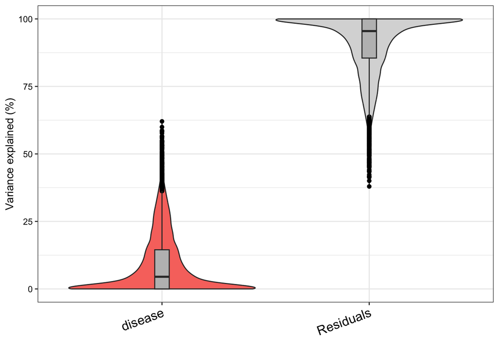

```r
# Violin plotで可視化
vp_plot <- plotVarPart(vp_result)
print(vp_plot)
```

```r
# diseaseの寄与が大きい上位遺伝子を確認
vp_sorted <- sortCols(vp_result)
head(vp_sorted, 20)
```

```
##                       disease Residuals
## ENSG00000000419.12 0.19594370 0.8040563
## ENSG00000000457.13 0.05234579 0.9476542
## ENSG00000000460.16 0.26965740 0.7303426
## ENSG00000000938.12 0.02895260 0.9710474
## ENSG00000000971.15 0.04898158 0.9510184
## ENSG00000001036.13 0.30853692 0.6914631
## ENSG00000001084.10 0.00000000 1.0000000
## ENSG00000001167.14 0.01949191 0.9805081
## ENSG00000001460.17 0.06350472 0.9364953
## ENSG00000001461.16 0.18921272 0.8107873
## ENSG00000001561.6  0.03090128 0.9690987
## ENSG00000001629.9  0.23226880 0.7677312
## ENSG00000001630.15 0.00000000 1.0000000
## ENSG00000001631.15 0.13835599 0.8616440
## ENSG00000002016.17 0.01709244 0.9829076
## ENSG00000002330.13 0.02301581 0.9769842
## ENSG00000002549.12 0.49476958 0.5052304
## ENSG00000002822.15 0.06009780 0.9399022
## ENSG00000002834.17 0.08527451 0.9147255
## ENSG00000002919.14 0.12549175 0.8745082
```

# edgeRによるDEG解析

edgeRについて： RNA-seqカウントデータのDEG解析のための代表的なBioconductorパッケージ。 負の二項分布モデルを用いて、サンプル間の遺伝子発現の差を統計的に検定する。

> Reference: Robinson MD, McCarthy DJ, Smyth GK. “edgeR: a Bioconductor package for differential expression analysis of digital gene expression data.” Bioinformatics. 2010;26(1):139-140. [doi:10.1093/bioinformatics/btp616](https://doi.org/10.1093/bioinformatics/btp616)

公式ユーザーガイド（式の書き方の詳細やさまざまな解析デザインの例が豊富）： https://bioconductor.org/packages/release/bioc/vignettes/edgeR/inst/doc/edgeRUsersGuide.pdf

**補足: DESeq2について** — DEG解析のもう一つの代表的なツール。 edgeRと同様に負の二項分布モデルを使うが、分散の縮小推定の方法が異なる。

> Reference: Love MI, Huber W, Anders S. “Moderated estimation of fold change and dispersion for RNA-seq data with DESeq2.” Genome Biology. 2014;15:550. [doi:10.1186/s13059-014-0550-8](https://doi.org/10.1186/s13059-014-0550-8)

## Quasi-likelihood (QL) F-test

edgeRにはLRT（尤度比検定）とQL F-testの2つの検定方法がある。 QL F-testは分散推定の不確実性を考慮するため、特にサンプル数が少ない場合に 偽陽性の制御が優れており、edgeR公式でも推奨されている。

各ステップの意味：

- `estimateDisp()` : 負の二項分布の分散パラメータを推定
- `glmQLFit()` : 準尤度（QL）負の二項GLMをフィットし、経験ベイズ法で遺伝子ごとのQL分散を縮小推定
- `glmQLFTest()` : QL F検定により、指定した係数についてDEGを検出

```r
print("疾患グループ：")
```

```
## [1] "疾患グループ："
```

```r
print(levels(pca_df$disease))
```

```
## [1] "HC"  "SLE"
```

```r
dge_filtered$samples$group <- factor(meta$disease[match(colnames(dge_filtered), meta$id)])

print("各疾患グループのサンプル数:")
```

```
## [1] "各疾患グループのサンプル数:"
```

```r
print(table(dge_filtered$samples$group))
```

```
##
##  HC SLE
##  64  61
```

```r
disease_groups <- levels(dge_filtered$samples$group)
reference_group <- disease_groups[1]
treatment_group <- disease_groups[2]
print(paste0("比較: ", treatment_group, " vs ", reference_group))
```

```
## [1] "比較: SLE vs HC"
```

```r
# デザインマトリックスの設定
# ~group は「切片 + グループ差」のモデル。SLE_vs_HC の係数がSLEとHCの差を表す。
design <- model.matrix(~group, data = dge_filtered$samples)
colnames(design) <- c("Intercept", paste0(treatment_group, "_vs_", reference_group))
head(design)
```

```
##          Intercept SLE_vs_HC
## NW100766         1         0
## NW102196         1         1
## NW102537         1         0
## NW103721         1         0
## NW103984         1         0
## NW105357         1         1
```

```r
# Step 1: 負の二項分布の分散を推定
dge_filtered <- estimateDisp(dge_filtered, design)

# Step 2: 準尤度GLMをフィット（経験ベイズによる分散の縮小推定を含む）
fit <- glmQLFit(dge_filtered, design)

# Step 3: QL F検定でDEGを検出
qlf <- glmQLFTest(fit, coef = paste0(treatment_group, "_vs_", reference_group))

# 結果の取得
results <- topTags(qlf, n = Inf, sort.by = "PValue")
results_df <- as.data.frame(results)

# 有意なDEGの数をカウント（FDR < 0.05）
de_genes_up <- sum(results_df$logFC > 0 & results_df$FDR < 0.05)
de_genes_down <- sum(results_df$logFC < 0 & results_df$FDR < 0.05)

print(paste0(treatment_group, "で発現上昇している遺伝子数（FDR < 0.05）: ", de_genes_up))
```

```
## [1] "SLEで発現上昇している遺伝子数（FDR < 0.05）: 4899"
```

```r
print(paste0(treatment_group, "で発現低下している遺伝子数（FDR < 0.05）: ", de_genes_down))
```

```
## [1] "SLEで発現低下している遺伝子数（FDR < 0.05）: 4174"
```

```r
# 結果にGene_nameを追加
results_df$Gene_id <- rownames(results_df)
results_df <- left_join(results_df, gene_info, by = "Gene_id")

print("DEG解析結果の上位:")
```

```
## [1] "DEG解析結果の上位:"
```

```r
head(results_df, 10)
```

```
##       logFC   logCPM        F       PValue          FDR            Gene_id Gene_name
## 1  3.719043 0.857770 248.5459 8.254415e-39 1.267631e-34  ENSG00000010319.6    SEMA3G
## 2  3.735843 0.832634 203.5737 8.125997e-34 6.239547e-30 ENSG00000102755.11      FLT1
## 3  5.800603 1.818518 207.4890 3.535302e-32 1.809721e-28  ENSG00000156234.7    CXCL13
## 4  2.426541 5.508255 237.6863 4.233470e-31 1.625335e-27 ENSG00000196141.13   SPATS2L
## 5  4.908879 7.504211 226.4687 3.191541e-30 9.802499e-27 ENSG00000165949.12     IFI27
## 6  2.134935 7.538286 211.6391 5.038369e-29 1.289570e-25 ENSG00000089127.12      OAS1
## 7  2.366544 8.956116 208.6104 8.995373e-29 1.817981e-25 ENSG00000157601.13       MX1
## 8  1.619474 4.559366 208.4036 9.470503e-29 1.817981e-25  ENSG00000107281.9     NPDC1
## 9  2.070336 5.952458 204.7737 1.896679e-28 3.236366e-25  ENSG00000184979.9     USP18
## 10 1.275615 7.982726 199.7878 5.028219e-28 7.721835e-25 ENSG00000138496.16     PARP9
```

# Volcano Plot

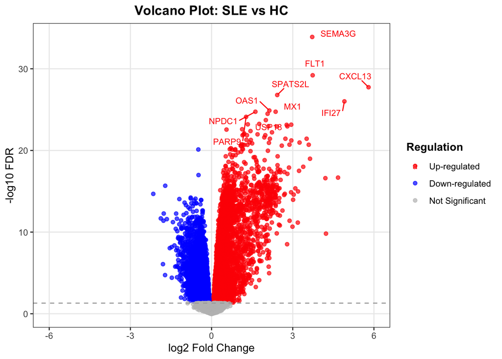

```r
volcano_data <- results_df
volcano_data$significance <- "Not Significant"
volcano_data$significance[volcano_data$logFC >= 0 & volcano_data$FDR < 0.05] <- "Up-regulated"
volcano_data$significance[volcano_data$logFC < 0 & volcano_data$FDR < 0.05] <- "Down-regulated"
volcano_data$significance <- factor(volcano_data$significance,
                                    levels = c("Up-regulated", "Down-regulated", "Not Significant"))

top_genes_label <- volcano_data %>%
  filter(FDR < 0.05) %>%
  arrange(FDR) %>%
  head(10)

volcano_plot <- ggplot(volcano_data, aes(x = logFC, y = -log10(FDR), color = significance)) +
  geom_point(alpha = 0.7) +
  geom_hline(yintercept = -log10(0.05), linetype = "dashed", color = "darkgray") +
  scale_color_manual(values = c("Up-regulated" = "red", "Down-regulated" = "blue", "Not Significant" = "gray")) +
  geom_text_repel(
    data = top_genes_label,
    aes(label = Gene_name),
    size = 3,
    max.overlaps = 20,
    box.padding = 0.5
  ) +
  labs(
    title = paste0("Volcano Plot: ", treatment_group, " vs ", reference_group),
    x = "log2 Fold Change",
    y = "-log10 FDR",
    color = "Regulation"
  ) +
  theme_bw() +
  xlim(-6, 6) +
  theme(
    plot.title = element_text(hjust = 0.5, face = "bold"),
    legend.position = "right",
    legend.title = element_text(face = "bold"),
    panel.grid.minor = element_blank()
  )

print(volcano_plot)
```

# ヒートマップ（上位50 DEG）

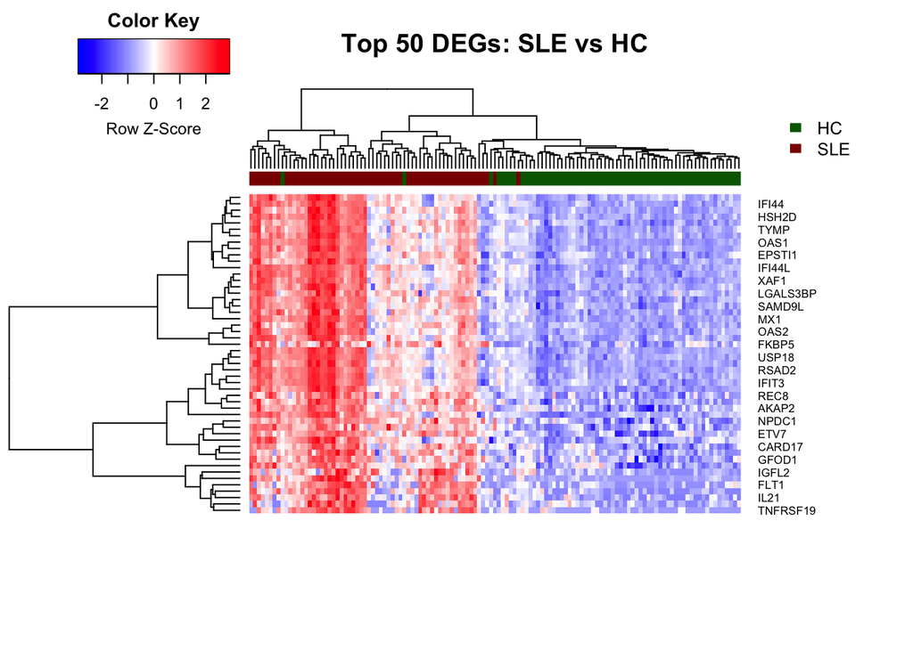

```r
top_degs <- results_df %>%
  filter(FDR < 0.05) %>%
  arrange(FDR) %>%
  head(50)

deg_expression <- log_cpm[top_degs$Gene_id, HC_SLE_samples]
rownames(deg_expression) <- top_degs$Gene_name

sample_order <- meta %>%
  filter(id %in% HC_SLE_samples) %>%
  arrange(disease) %>%
  pull(id)

deg_expression <- deg_expression[, sample_order]

my_palette <- colorRampPalette(c("blue", "white", "red"))(n = 100)

disease_colors <- c("darkgreen", "darkred")
names(disease_colors) <- c("HC", "SLE")

sample_disease <- meta$disease[match(colnames(deg_expression), meta$id)]
col_colors <- disease_colors[sample_disease]

heatmap.2(as.matrix(deg_expression),
          col = my_palette,
          scale = "row",
          trace = "none",
          density.info = "none",
          key = TRUE,
          keysize = 1.5,
          ColSideColors = col_colors,
          margins = c(8, 10),
          cexRow = 0.8,
          cexCol = 0.8,
          labCol = FALSE,
          main = "Top 50 DEGs: SLE vs HC",
          dendrogram = "both")

legend("topright",
       legend = c("HC", "SLE"),
       fill = disease_colors,
       border = FALSE,
       bty = "n",
       cex = 0.8)
```

# Pathway解析（IFN関連遺伝子のエンリッチメント）

```r
# IFN関連遺伝子グループの読み込み
IFNgenes <- read.table(ifn_genes_file, header = F)[, 1]
head(IFNgenes)
```

```
## [1] "OAS3"   "PLSCR1" "CMPK2"  "MX2"    "STAT2"  "PARP14"
```

```r
length(IFNgenes)
```

```
## [1] 100
```

```r
# 発現データに含まれるIFN遺伝子に絞る
expressed_genes_ids <- rownames(dge_filtered)
expressed_genes_names <- gene_info$Gene_name[match(expressed_genes_ids, gene_info$Gene_id)]
expressed_genes_names <- expressed_genes_names[!is.na(expressed_genes_names) & expressed_genes_names != ""]

filtered_IFNgenes <- intersect(IFNgenes, expressed_genes_names)
print(paste0("発現データに含まれるIFN遺伝子数: ", length(filtered_IFNgenes)))
```

```
## [1] "発現データに含まれるIFN遺伝子数: 95"
```

```r
# 発現上昇/低下DEGを取得
up_DEGs <- results_df %>%
  filter(FDR < 0.05 & logFC > 0) %>%
  pull(Gene_name)

down_DEGs <- results_df %>%
  filter(FDR < 0.05 & logFC < 0) %>%
  pull(Gene_name)

print(paste0("発現上昇DEG数: ", length(up_DEGs)))
```

```
## [1] "発現上昇DEG数: 4899"
```

```r
print(paste0("発現低下DEG数: ", length(down_DEGs)))
```

```
## [1] "発現低下DEG数: 4174"
```

```r
# IFN遺伝子と発現上昇/低下DEGの重複を確認
ifn_in_up_DEGs <- intersect(up_DEGs, filtered_IFNgenes)
print(paste0("発現上昇したIFN関連遺伝子数: ", length(ifn_in_up_DEGs)))
```

```
## [1] "発現上昇したIFN関連遺伝子数: 85"
```

```r
ifn_in_down_DEGs <- intersect(down_DEGs, filtered_IFNgenes)
print(paste0("発現低下したIFN関連遺伝子数: ", length(ifn_in_down_DEGs)))
```

```
## [1] "発現低下したIFN関連遺伝子数: 3"
```

## Fisherの正確確率検定

```r
total_genes <- length(expressed_genes_names)

contingency_up <- matrix(c(
  length(ifn_in_up_DEGs),
  length(up_DEGs) - length(ifn_in_up_DEGs),
  length(filtered_IFNgenes) - length(ifn_in_up_DEGs),
  total_genes - length(up_DEGs) - (length(filtered_IFNgenes) - length(ifn_in_up_DEGs))
), nrow = 2)

rownames(contingency_up) <- c("IFN", "non-IFN")
colnames(contingency_up) <- c("upDEG", "non-upDEG")

print("発現上昇DEGに対するIFN遺伝子の2x2Table:")
```

```
## [1] "発現上昇DEGに対するIFN遺伝子の2x2Table:"
```

```r
contingency_up
```

```
##         upDEG non-upDEG
## IFN        85        10
## non-IFN  4814     10448
```

```r
# Fisherの正確確率検定
fisher_test_up <- fisher.test(contingency_up, alternative = "greater")
print("発現上昇DEGに対するIFN遺伝子のエンリッチメント分析結果:")
```

```
## [1] "発現上昇DEGに対するIFN遺伝子のエンリッチメント分析結果:"
```

```r
print(fisher_test_up)
```

```
##
##  Fisher's Exact Test for Count Data
##
## data:  contingency_up
## p-value < 2.2e-16
## alternative hypothesis: true odds ratio is greater than 1
## 95 percent confidence interval:
##  10.43299      Inf
## sample estimates:
## odds ratio
##   18.44551
```

# HTMLレポートの生成（任意）

このスクリプトの実行結果をHTMLレポートとして保存したい場合、 RStudioのコンソールで以下を実行してください：

```r
rmarkdown::render("day3_bulk_DEG.R", output_format = rmarkdown::html_document(toc = TRUE, toc_float = TRUE, theme = "flatly", code_folding = "show"))
```

同じフォルダに `day3_bulk_DEG.html` が生成されます。 `#'` で始まる行が見出し・説明文として、それ以外がコードチャンクとしてレンダリングされます。